# Multiverse analysis study - Tutorial

## Introduction

Data analyses for any scientific research in an iterative, multi-stage process. The statistical results that are reported in a published paper are usually one of many reasonable analyses arising from the iterative process. A multiverse analysis aims to increase transparency by performing multiple analyses on a given dataset based on a set of defensible analysis procedures. In this tutorial, we will look at a simple example and you will complete extend the example in the following activity.

## Learning objectives

In this tutorial, you will practice defining and exploring a set of multiple analyses for a given dataset in R. You will:

- define multiple models using purpose-built package, `mverse`,
- fit the models using `lm_mverse()`,
- extract and save quantities of interest from the fitted models, and
- organize and visualize the extracted quantities to help answer a research question.

## Data

We are given a dataset that contains information on mortgage applications made in 1990 in Boston. We can read the dataset and store it in `hdma` as shown below. You can run the code below by clicking the green arrow button on the right of the code chunk or pressing ‘Ctrl + Shift + Enter’ with your cursor inside the code chunk to view the dataset.

```r
# the dataset is stored in the file named hdma.csv
hdma <- read.csv("hdma.csv")
hdma
```

| is_approved | is_female | is_black | is_married | is_housing_expense_ratio_high | is_self_employed | is_bad_credit | payment_income_ratio | loan_to_value_ratio |
| --- | --- | --- | --- | --- | --- | --- | --- | --- |
| 1 | 1 | 0 | 1 | 0 | 0 | 0 | 22.100 | 80.000000 |
| 1 | 0 | 0 | 0 | 0 | 0 | 0 | 26.500 | 92.187500 |
| 1 | 0 | 0 | 1 | 0 | 0 | 0 | 37.200 | 92.039801 |
| 1 | 0 | 0 | 1 | 0 | 0 | 0 | 32.000 | 86.046512 |
| 1 | 0 | 0 | 1 | 1 | 0 | 0 | 36.000 | 60.000000 |
| 1 | 0 | 0 | 1 | 0 | 0 | 0 | 24.000 | 51.052632 |
| 1 | 1 | 0 | 0 | 0 | 0 | 0 | 35.000 | 74.666667 |
| 1 | 0 | 0 | 1 | 0 | 0 | 0 | 28.000 | 85.000000 |
| 0 | 0 | 0 | 1 | 0 | 0 | 0 | 31.000 | 89.726027 |
| 1 | 0 | 1 | 1 | 0 | 0 | 0 | 24.000 | 94.814815 |

[output cut: 2499 more lines]

Each row of the dataset represents a mortgage application with the following information in the columns:

- `is_approved` is 1 if the application was approved and 0 otherwise.
- `is_female` is 1 if the applicant was a female and 0 otherwise.
- `is_black` is 1 if the applicant was a black or Hispanic and 0 if the applicant was non-Hispanic white. The dataset does not contain other races.
- `is_married` is 1 if the applicant was married and 0 otherwise.
- `is_housing_expense_ratio_high` is 1 if the bank’s calculation of housing expense over income exceeds 30% and 0 otherwise.
- `is_self_employed` is 1 if the applicant was self-employed and 0 otherwise.
- `is_bad_credit` is 1 if the applicant had one or more public records such as bankruptcy, charge offs, and collection actions and 0 otherwise.
- `payment_income_ratio` is the bank’s calculation of total debt payment over income in percentages.
- `loan_to_value_ratio` is the value of the loan amount over the appraisal value of the property in percentages.

## Research question

We are interested in answering the following research question.

> Did mortgage providers approve an application differently based on the applicant’s sex in Boston in 1990?

To answer the question, we can conduct a hypothesis test with the following set of hypotheses.

> - $H_0$: No, they were as likely to approve female applicants as male applicants.
> - $H_1$: Yes, they were either more likely or less likely to approve female applicants than male applicants.

We will conduct the test at 5% significance level, or 95% confidence level.

*Recall that a hypothesis test investigates whether a given data set provides evidence against the null hypothesis, $H_0$, which leads to the that the alternative hypothesis, $H_1$ is true.*

## A simple linear regression model

One way to conduct the hypothesis test for the given research question is the t-test for a single regression coefficient in a linear regression model. For example, we can fit the following simple linear regression model.

$$IsApproved_i = \beta_0 + \beta_1
IsFemale_i + \varepsilon_i$$

where $IsApproved_i$ is `is_approved` and $IsFemale_i$ is `is_female` for $i$th application in the dataset `hdma`.

In R, we can write the formula as `is_approved ~ is_female`. To fit the linear regression model, we can pass the formula and along with the dataset to the function `lm()` as below. Calling the `summary()` function on the fitted object provides a quick summary of the model.

**Run** the code below. This provides a summary of the fitted simple linear regression model.

```r
fit <- lm(formula = is_approved ~ is_female, data = hdma)
summary(fit)
```

```
##
## Call:
## lm(formula = is_approved ~ is_female, data = hdma)
##
## Residuals:
##     Min      1Q  Median      3Q     Max
## -0.8795  0.1205  0.1254  0.1254  0.1254
##
## Coefficients:
##             Estimate Std. Error t value Pr(>|t|)
## (Intercept) 0.874622   0.007407 118.074   <2e-16 ***
## is_female   0.004919   0.016224   0.303    0.762
## ---
## Signif. codes:  0 '***' 0.001 '**' 0.01 '*' 0.05 '.' 0.1 ' ' 1
##
## Residual standard error: 0.3301 on 2507 degrees of freedom
## Multiple R-squared:  3.666e-05,  Adjusted R-squared:  -0.0003622
## F-statistic: 0.09191 on 1 and 2507 DF,  p-value: 0.7618
```

The summary table provides the estimated coefficient of the term $IsFemale$, which is 0.004919. Recall that in the given dataset, a unit increase in $IsFemale$ indicates the applicant’s sex being female, 1, vs. male, 0. Thus, the coefficient is the mean gain in $IsApproved$ for female applicants vs. male applicants. $IsApproved$ was also encoded using 0 and 1 with 1 indicating an approved application. One way to interpret the result is that female applicants were approved for their mortgage applications with 0.4919% higher probability on average. However, this value does not indicate whether the difference is statistically significant.

The table provides the two-sided p-value for $IsFemale$, 0.762. When this value is smaller than the predefined significance level, we could conclude that the coefficient for $IsFemale$ does not equal to 0 at the significance level. In this case, since it is larger than our significance level, 0.05, we conclude that the result is not statistically significant and do not reject the null hypothesis.

> Using the the simple linear regression model, we do not find statistically significant evidence that an applicant’s sex was relevant in the probability of approval for their mortgage application. We fail to reject the null hypothesis that mortgage providers were as likely to approve female applicants as male applicants.

Alternatively, we can extract the 95% confidence interval for the coefficient estimate using `confint()`. The function by default outputs a table with 95% confidence intervals for all coefficients and the intercept. We can extract confidence interval for the $IsFemale$ term only by using the row name.

**Run** the code below. The code displays both the table of confidence intervals for all terms and the confidence interval extracted for the $IsFemale$ term.

```r
ci <- confint(fit)
ci # all confidence intervals
```

```
##                   2.5 %     97.5 %
## (Intercept)  0.86009706 0.88914765
## is_female   -0.02689571 0.03673321
```

```r
ci[row.names(ci) == "is_female", ] # extracting the is_female coefficient ci
```

```
##       2.5 %      97.5 %
## -0.02689571  0.03673321
```

*Recall that in R, you can select a subset of the rows in a table by passing the desired condition in the first index while leaving the second index empty, `<table>[<condition> , ]`.*

We can make the same conclusion that we can not reject the null hypothesis based on the fact that the confidence interval, (-0.027, 0.037), includes 0.

### *Practice*

Mortgage providers consider the applicant’s financial information when assessing an application. One may argue that the analysis above doesn’t consider this and that the following model is a better model to answer the research question.

$$IsApproved_i = \beta_0 + \beta_1
IsFemale_i + \beta_2 PaymentIncomeRatio_i + \varepsilon_i$$

where $IsApproved_i$ is `is_approved`, $IsFemale_i$ is `is_female`, and $PaymentIncomeRatio_i$ is `payment_income_ratio` for $i$th application in the dataset `hdma`.

In the code chunk provided below, fit the multiple linear regression defined above and extract the 95% confidence interval for the $IsFemale$ term.

```r
# write your code here
```

## Multiverse analysis

The dataset includes more than the payment to income ratio for each application. It includes other information about the applicant’s financial information as well as other demographic information. The mortgage providers also had access to them when making their decisions. However, it’s difficult to say that all of the information were relevant when making the decisions on the approvals.

Assume that any combination of the extra variables, or covariates, included in the dataset makes a defensible model for answering the research question. A multiverse analysis analyzes and reports results from all of the defensible models. For this tutorial, we will only consider `payment_income_ratio` and `is_married` as covariates.

### Defining the multiverse

With the 2 covariates, we can construct 4 defensible models in the following ways:

1. Do not include either `payment_income_ratio` or `is_married`
2. Include only `payment_income_ratio`
3. Include only `is_married`
4. Include both `payment_income_ratio` and `is_married`

> We will use the package `mverse`. The package is designed specifically to help define and explore multiverse analysis easily.

**Run** each of the code chunks below to define the multiverse with the package.

1. Install and load the package.

```r
# The installation process may ask you to update other packages.
# Select the option to update All.
remotes::install_github("mverseanalysis/mverse")
library(mverse)
```

2. Define the decision branch. In `mverse`, each decision point is called a branch. `formula_branch()` defines options around the model formula.

You can specify the 4 models manually by typing the formulae in the function:

```r
formulae <- formula_branch(
  is_approved ~ is_female,
  is_approved ~ is_female + payment_income_ratio,
  is_approved ~ is_female + is_married,
  is_approved ~ is_female + payment_income_ration + is_married
  )
formulae
```

```
## <unnamed branch>  Options
##     - (is_approved ~ is_female)
##     - (is_approved ~ is_female + payment_income_ratio)
##     - (is_approved ~ is_female + is_married)
##     - (is_approved ~ is_female + payment_income_ration + is_married)
```

Or, you can pass the two covariates to the optional argument `covariate =` to specify that they are optional in forming the model formula and all combinations need to be used.

```r
formulae <- formula_branch(
  is_approved ~ is_female,
  covariates = c("payment_income_ratio", "is_married")
  )
formulae
```

```
## <unnamed branch>  Options
##     - "is_approved ~ is_female"
##     - "is_approved ~ is_female + payment_income_ratio"
##     - "is_approved ~ is_female + is_married"
##     - "is_approved ~ is_female + payment_income_ratio + is_married"
```

3. Define a multiverse based on the branch. In `mverse`, any multiverse analysis is defined by a source dataset and a set of branches. We can make use of R’s pipe operator, `|>`, to create a multiverse analysis object with the source dataset and consecutively add the formula branch defined above.

```r
mv <- create_multiverse(hdma) |>
  add_formula_branch(formulae)
# the
mv
```

```
## Multiverse
##
##   Multiverse consists of 4 different analyses
##
##    Parameters:
##      Parameter name: formulae_branch
##         options: formulae_1 formulae_2 formulae_3 formulae_4
##
##    Conditions:
##      No conditions have been defined yet
```

*Note that all 4 models include `is_approved` as the response variable and `is_female` as an explanatory variable since we are interested in the relationship between the two.*

### Fitting the multiverse

`mverse` provides a set of functions that makes it easy to fit `lm()` across the multiverse and extract the summary values.

For each of the model in the multiverse, we will

1. fit the linear regression model using the dataset `hdma`,
2. extract the coefficient estimate and 95% confidence interval for `is_female`, and
3. store the extracted estimate and confidence interval.

**Run** each of the code chunks below to define the multiverse with the package.

1. Fit the linear regression models using `lm_mverse()`. With a single call, you can fit all models defined in the multiverse.

```r
mv <- lm_mverse(mv)
```

2. Extract and store summary values associated with `is_female`. `spec_summary()` allows you to extract the regression coefficient, p-values, 95% confidence intervals, and other statistics associated with the term from each regression model.

```r
results <- spec_summary(mv, "is_female")
results
```

| universe | term | estimate | p.value | conf.low | conf.high | formulae_branch | formulae_branch_code | is_significant |
| --- | --- | --- | --- | --- | --- | --- | --- | --- |
| 1 | is_female | 0.004918752 | 0.7617844 | -0.026895707 | 0.03673321 | formulae_1 | "is_approved ~ is_female" | FALSE |
| 2 | is_female | 0.004978366 | 0.7530682 | -0.026048895 | 0.03600563 | formulae_2 | "is_approved ~ is_female + payment_income_ratio" | FALSE |
| 3 | is_female | 0.028984670 | 0.1021772 | -0.005777891 | 0.06374723 | formulae_3 | "is_approved ~ is_female + is_married" | FALSE |
| 4 | is_female | 0.026845740 | 0.1207392 | -0.007068640 | 0.06076012 | formulae_4 | "is_approved ~ is_female + payment_income_ratio + is_married" | FALSE |

### Exploring the multiverse

In this tutorial example, we only considered decisions around inclusion and exclusion of 2 out of 7 covariates. As you will see in the following activity, a multiverse analysis can be complex and large. It is therefore important to organize and represent the results in a human-readable format to help answering the research question.

First, we will present the result in a table. The output of `spec_summary()` is compatible with `tidyverse`. We can manipulate using functions from `dplyr` package.

**Run** the following code. We can use square bracket extractor to select the columns we want to display in order. `formulae_branch` and `formulae_branch_code` contain the short form named of the formula branch options and the code used to define them. The column names are dereived from `formulae` variable name. `estimate`, `conft.low`, and `conf.high` are the coefficient estimate, lower bound of the confidence interval, and upper bound of the confidence interval respectively.

```r
results[ , c("formulae_branch", "formulae_branch_code",
             "estimate", "conf.low", "conf.high")]
```

| formulae_branch | formulae_branch_code | estimate | conf.low | conf.high |
| --- | --- | --- | --- | --- |
| formulae_1 | "is_approved ~ is_female" | 0.004918752 | -0.026895707 | 0.03673321 |
| formulae_2 | "is_approved ~ is_female + payment_income_ratio" | 0.004978366 | -0.026048895 | 0.03600563 |
| formulae_3 | "is_approved ~ is_female + is_married" | 0.028984670 | -0.005777891 | 0.06374723 |
| formulae_4 | "is_approved ~ is_female + payment_income_ratio + is_married" | 0.026845740 | -0.007068640 | 0.06076012 |

We now have a table that presents the results from the multiverse analysis in a human-readable manner. From the table, we can see that all 4 analyses resulted in 95% confidence intervals that contain 0. We can also see from the table that including `is_married` as the covariate alone resulted in the largest coefficient estimate.

Visualizing the table can help explore and deduce conclusions from the multiverse analysis. `mverse` includes functions that allow exploration of the multiverse visually.

**Run** the following code. `spec_curve()` from `mverse` plots the coefficient estimates and the confidence intervals using outputs from `spec_summary()`. By default, the function also uses colours to distinguish statistically significant results.

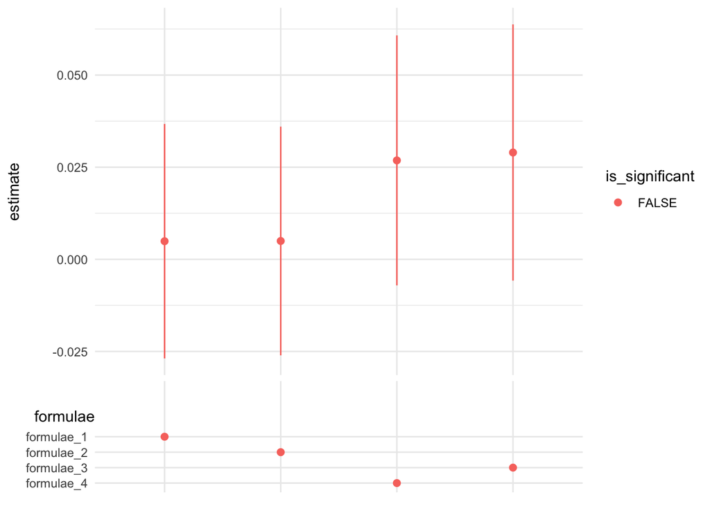

```r
spec_curve(results)
```

From the plot above, we can tell that while all 4 models resulted in positive coefficient estimates, the 95% confidence intervals all contain 0. The function also plots the analyses sorted by the size of the coefficient estimates. The visual table at the bottom indicates to which model option each result belongs. By default the short form names are displayed. We can also display the specified model explicitly.

**Run** the code below. `label = "code"` option in `spec_curve()` displays the code used to define the branch options instead of the short form names.

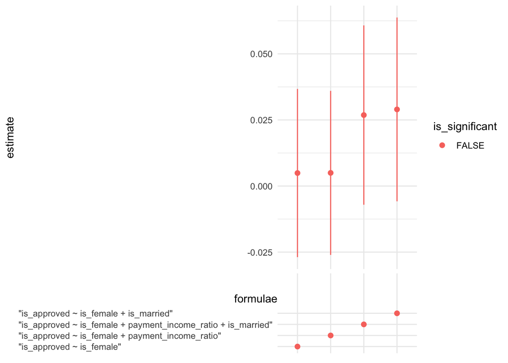

```r
spec_curve(results, label = "code")
```

Looking at the plot, it’s clear that including `is_married` in the regression model resulted in higher coefficient estimates for `is_female`. To highlight the comparison between models with and without `is_married`, we can visually group the values by whether the model includes `is_married`.

**Run** the code below. `grepl(x, y)` returns a vector consisting of `TRUE` if the character `x` is detected in each value of vector `y` and `FALSE` otherwise. We can check the `formulae_branch_code` to identify which models include `is_married` and add a new column to save the information. Using the new column in `spec_curve()`’s `colour_by` option, we can change the colour scheme to distinguish results from models that include `is_married`.

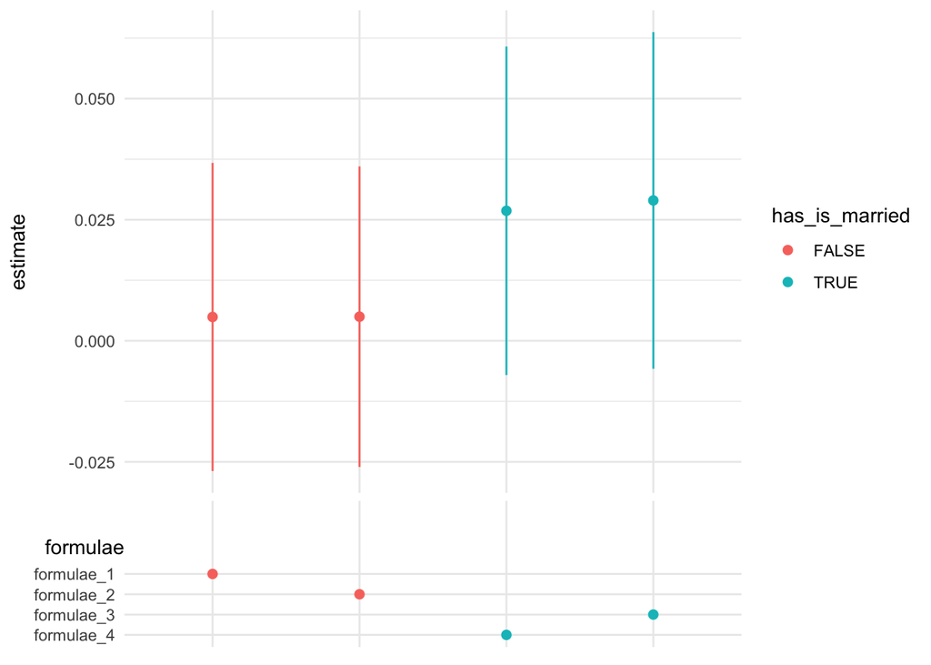

```r
results["has_is_married"] <- grepl("is_married", results$formulae_branch_code)
spec_curve(results, colour_by = "has_is_married")
```

Suppose you want to highlight the model that includes both `is_married` and `payment_income_ratio`. You can use `&` to combine more than one logical checks to check that all of them are true. `order_by = "has_both"` in `spec_curve()` sorts the values so that the model with both covariates are appear on the right.

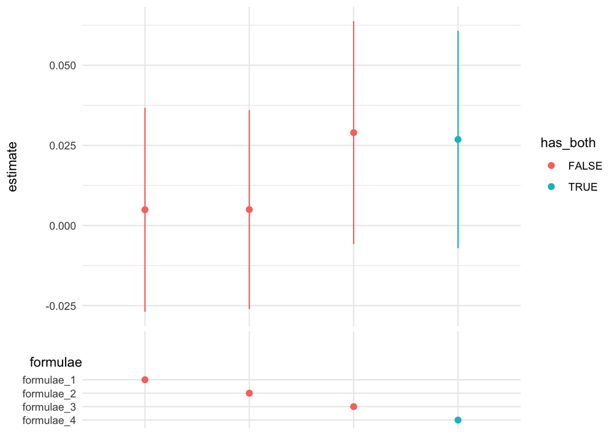

```r
results["has_both"] <- grepl("is_married", results$formulae_branch_code) &
  grepl("payment_income_ratio", results$formulae_branch_code)
spec_curve(results, colour_by = "has_both", order_by = "has_both")
```

Alternatively, you can make use of `ggplot2` library’s functions because `spec_curve()`’s output is a `ggplot` object. For example, you can use `facet_grid()` to isolate those with both covariates in different a different row as shown below. This method allows you to keep the colour scheme for statistical significance.

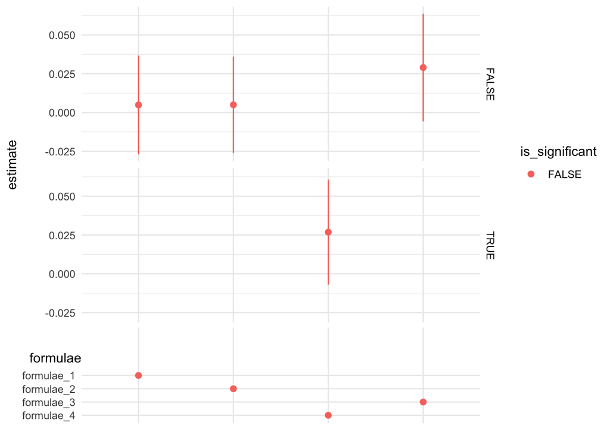

```r
library(ggplot2)
spec_curve(results) +
  facet_grid(rows = vars(has_both))
```

*Note: Using column facets with `spec_curve()` is not recommended as repeating the table at the bottom causes overlaps.*

> In all 4 models fitted in the multiverse analysis, we do not find statistically significant evidence that an applicant’s sex was relevant in the probability of approval for their mortgage application. The multiverse analysis further strengthened our conclusion from the simple linear regression analysis with no covariates. However, it’s worth noting that including the information about an applicant’s marital status visibly increased the estimated effect size.

Indeed, you will see that the larger multiverse analysis in the following activity consists of results that are both statistically significant and not.

> Knit the current document by clicking `knit` button at the top ro pressing `Shift + Ctrl + K`. Proceed back to the Quercus quiz. For the following activity, keep the rendered `tutorial.html` document open for reference.